# Boletin Técnico Agroclimático Nacional - Distritos de Riego

Author

Servicio Climático – Fedearroz

[figure not shown]

Boletín Nro 1 Emisión de 5 de agosto de 2025, Actualización Nro: 1

# Contexto climático Nacional para julio

[figure not shown]

Figure 1: Anomalía de la precipitación en Colombia

#### Análisis de la situación de precipitación

Por otro lado, se identificaron déficits de lluvia preocupantes en varias regiones. En el **Centro** del país, el **Tolima** reportó reducciones de precipitaciones superiores al 80%, afectando potencialmente el cultivo de arroz. En el **Caribe Seco**, sectores de **La Guajira**, **Cesar**, y **Norte de Magdalena** también presentaron reducciones significativas. En el Caribe Húmedo, se observaron déficits en **Bolívar** y sectores de **Antioquia** y **Córdoba**. Adicionalmente, en los **Llanos**, el norte de **Arauca** experimentó disminuciones entre el 20% y 40%, lo que indica una situación crítica en esta área agrícola.

La temporada seca de mitad de año, que se prevé para agosto, dependerá del comportamiento de las ondas tropicales. Se recomienda estar atentos a posibles amenazas hidrometeorológicas, especialmente en zonas de alta pendiente.

Esta información fue extraída del **Boletín Agrometeorológico Semanal** del IDEAM.

[figure not shown]

Figure 2: Anomalía de la Temperatura Máxima

[figure not shown]

Figure 3: Anomalía de la Temperatura Mínima

#### Análisis de variación de temperatura

En el mes de agosto, se identificaron las siguientes anomalías en las temperaturas máximas y mínimas en Colombia:

**Temperatura Máxima:**

Los departamentos con las mayores anomalías en temperatura máxima se encuentran en el occidente de Boyacá, occidente de Caldas, norte de Risaralda, norte del Valle del Cauca, centro-oriente de Cauca, sur de Huila, suroccidente de Arauca, centro de Caquetá y oriente de Vaupés. En estas áreas, se pronostica que las temperaturas podrían superar lo normal en un rango de 0.5 a 1.0°C. Por otro lado, el sur de Santander y el occidente de Putumayo experimentarán temperaturas máximas por debajo de lo normal.

**Temperatura Mínima:**

En cuanto a las anomalías de temperatura mínima, se destacan las áreas del centro-occidente de Cundinamarca y centro-oriente de Cauca, donde se prevén valores superiores a lo normal, entre 0.5 y 1.0°C. En contraste, se anticipan temperaturas mínimas por debajo de lo normal en el suroccidente de Cundinamarca.

**Implicaciones para el cultivo de arroz:**

Las anomalías en las temperaturas máximas en las zonas arroceras, especialmente aquellas que superan los 1.5°C, pueden tener efectos adversos en las estructuras reproductivas del arroz, particularmente durante las etapas de floración y llenado de grano. En estas fases críticas, el exceso de calor puede provocar una reducción en el rendimiento y calidad del grano, afectando así la producción. Por lo tanto, es esencial monitorear las condiciones climáticas para implementar medidas adecuadas de manejo agronómico y mitigar los riesgos asociados a estas variaciones de temperatura.

Fuente: BAM-IDEAM

[figure not shown]

Figure 4: Índice de disponibilidad Hídrica (IDH)

#### Análisis de Disponibilidad Hídrica (IDH)

Durante el mes de julio, se observaron condiciones de disponibilidad hídrica muy secas en varias zonas arroceras del país. Los departamentos con niveles más bajos del Índice de Disponibilidad Hídrica incluyen:

- **Centro**: Tolima y Huila (condiciones Muy Seco y Seco).
- **Caribe Seco**: La Guajira, Norte de Santander, Cesar y Magdalena (también con índices de Seco y Muy Seco).

Por otro lado, las regiones con niveles altos de disponibilidad hídrica se encuentran en el norte y nororiente de la región Andina, así como en las regiones Pacífica, Orinoquía y Amazonía, donde se registraron condiciones muy húmedas.

Estos niveles de disponibilidad hídrica tienen implicaciones significativas para la demanda de riego en los cultivos de arroz. Las zonas con condiciones muy secas, como el Tolima y Huila, requieren un manejo más intensivo del riego debido a la escasa humedad del suelo, lo que puede afectar el crecimiento y rendimiento de los cultivos. En contraste, las áreas con un índice más alto pueden beneficiarse de un riego menos frecuente.

Para optimizar el uso del agua y garantizar la salud de los cultivos de arroz, se recomienda:

1. **Ajustar los esquemas de riego** en las zonas afectadas, implementando riegos más frecuentes y con mayor volumen de agua en Tolima y Huila.
2. **Monitorear continuamente los niveles de humedad del suelo** para adaptar las estrategias de riego según las necesidades.
3. **Considerar el uso de tecnologías de riego eficientes**, como el riego por goteo, que puede ayudar a maximizar el uso del agua en condiciones de escasez.

Implementar estas recomendaciones puede contribuir a mitigar los efectos adversos de la sequía en la producción de arroz.

Fuente: BAM-IDEAM

# Fenómenos de Variabilidad Climática

La variabilidad climática en Colombia está fuertemente influenciada por fenómenos como el El Niño-Oscilación del Sur (ENSO) y la Oscilación Madden–Julian (MJO). Actualmente, el ENSO se encuentra en un estado neutral, aunque se anticipa un aumento de condiciones de La Niña hacia finales de 2025, lo que podría afectar los patrones de precipitación y temperatura en el país. Por otro lado, la MJO está en fases que sugieren un aumento de la actividad convectiva, lo que podría resultar en un incremento de las lluvias en las próximas semanas, especialmente en regiones como el Pacífico y áreas andinas. Para los agricultores, es crucial mantenerse informado sobre estas dinámicas, ya que pueden influir en la disponibilidad de agua y requerimientos de riego, impactando directamente en la producción agrícola y la planificación de cultivos.

## Fenómeno de El Niño - La Niña (ENSO - Oscilacion del sur)

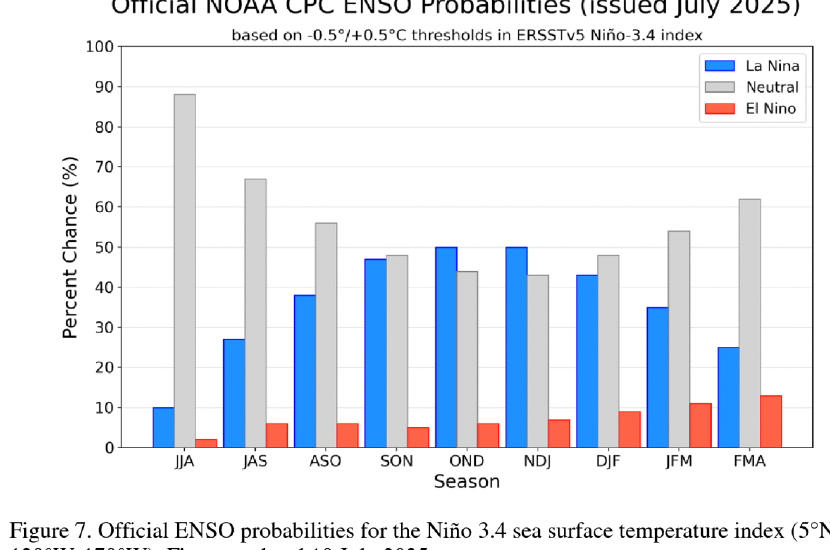

Figure 5: Evolución del índice ENSO

Actualmente, el fenómeno ENSO se encuentra en estado neutral, con temperaturas superficiales del mar (SST) casi promedio en gran parte del océano Pacífico. Se prevé que esta situación de ENSO-neutral continúe hasta finales del período de verano en el hemisferio norte de 2025, con un 56% de probabilidad. Sin embargo, se anticipa un aumento en las condiciones de La Niña hacia el otoño e invierno de 2025-26. Recientemente, se han observado anomalías de SST por encima de lo normal en el océano Pacífico occidental y extremo oriental, mientras que el resto del Pacífico presenta temperaturas cercanas o por debajo de la media.

Actualmente, la cuenca ENSO se encuentra en un estado neutro. Las anomalías de calor en el océano superior son cercanas a la media, y la pendiente del termoclina está en niveles cercanos a lo normal. En la región central y oriental del Pacífico, las anomalías de temperatura han mostrado un debilitamiento de las anomalías negativas, pero en las últimas semanas han comenzado a fortalecerlas nuevamente. Esto indica que los agricultores deben estar atentos a posibles cambios en las condiciones climáticas, ya que podrían influir en los patrones de precipitación y temperatura en los próximos meses.

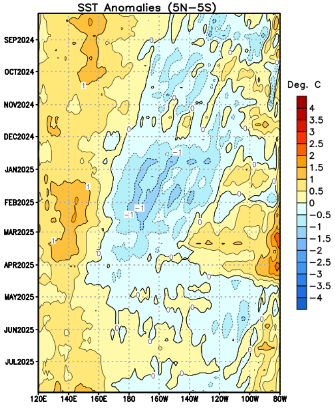

Figure 6: Evolución Reciente del Pacifico Ecuatorial ENSO

La actividad de ondas Kelvin en el Pacífico ecuatorial indica un patrón fluctuante que puede influir en el clima colombiano. La presencia de temperaturas subsuperficiales por debajo del promedio podría generar ingresos de humedad en algunas regiones, favoreciendo cultivos. Sin embargo, la debilidad de las temperaturas por encima del promedio en el Pacífico occidental podría limitar este efecto. Los agricultores deben prepararse para variaciones climáticas, ya que estos fenómenos podrían alterar patrones de lluvias y temperaturas, afectando la producción agrícola y la planificación de cultivos. Es crucial monitorear estas condiciones para tomar decisiones informadas.

El Oceanic Niño Index (ONI) es crucial para comprender el fenómeno ENSO en Colombia. Un ONI positivo (El Niño) indica un aumento en las temperaturas del mar, lo que conlleva a sequías y estrés hídrico, afectando negativamente el cultivo de arroz. Durante El Niño, los agricultores deben prepararse para condiciones secas y ajustar sus estrategias de riego. En contraste, un ONI negativo (La Niña) trae lluvias intensas y temperaturas más frescas, beneficiando el crecimiento del arroz, pero también puede provocar inundaciones. Por lo tanto, el monitoreo del ONI permite a los agricultores tomar decisiones informadas para optimizar la producción y mitigar riesgos climáticos.

## Oscilación Madden and Julian (MJO)

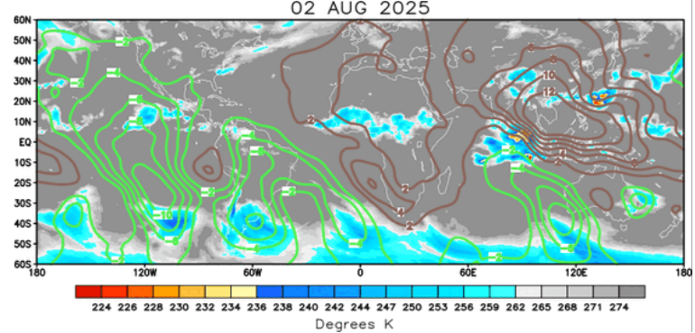

La Oscilación Madden–Julian (MJO) es un patrón de variabilidad climática que influye en las lluvias en Colombia al afectar la actividad convectiva en la atmósfera, lo que puede provocar sequías o lluvias intensas. Actualmente, la MJO se encuentra en fases 1-3, lo que sugiere un aumento en la actividad convectiva en la región. Esto podría resultar en un ambiente más favorable para las lluvias en las próximas semanas, aunque hay incertidumbre debido a otros factores climáticos que podrían interferir. Esta dinámica puede ser crucial para los agricultores, ya que afecta la disponibilidad de agua para los cultivos.

Fuente: CPC-NOAA.

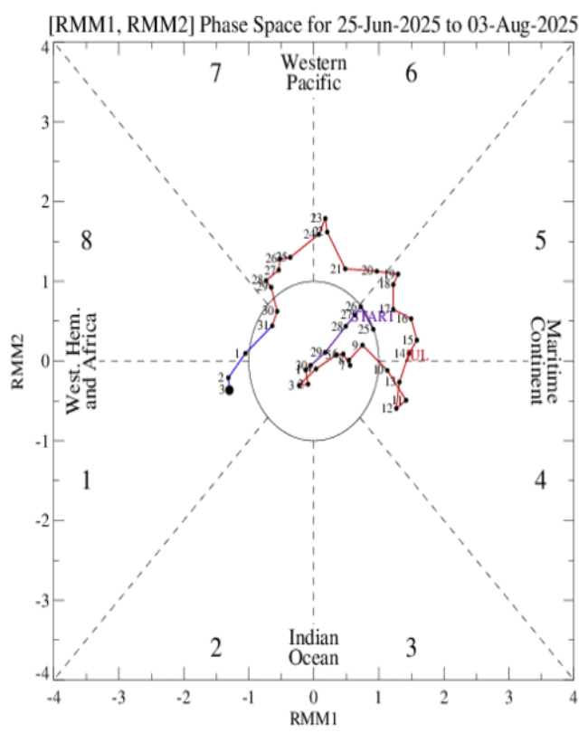

En la segunda quincena de julio, la Oscilación Madden–Julian (MJO) presenta una señal que ha estado mayormente fuera del círculo unitario, avanzando rápidamente desde el Pacífico occidental hacia África. Esta evolución indica una posible transición hacia condiciones más activas en términos de convección en otras regiones, incluyendo América Latina.

Para la semana 1, hasta fin de julio, se espera una intensificación de la convección en Colombia, especialmente en la región del Pacífico y áreas andinas. Esto podría traducirse en un aumento de las lluvias, beneficiando a los cultivos que requieren humedad, aunque también se debe estar alerta a posibles inundaciones o desbordamientos en zonas vulnerables. Las proyecciones sugieren un ambiente propicio para el desarrollo de sistemas convectivos que pueden generar lluvias significativas.

En la semana 2, durante la primera semana de agosto, la señal de la MJO podría seguir evolucionando hacia el este, aunque se prevé que su amplitud disminuya al atravesar el océano Índico, lo que podría moderar las condiciones de convección en Colombia. Comparando los pronósticos del GEFS y los análogos, ambos modelos indican un patrón similar de convección, pero el GEFS muestra una evolución más robusta en el ámbito de las Américas, sugiriendo que, aunque la intensidad de las lluvias podría disminuir, aún se mantendrán episodios de precipitación intermitente.

# Predicción Climática de la precipitación para las Cuencas

# Cuencas Zona Centro

## Cuenca Cucuana - Tolima

La cuenca del río Cucuana, ubicada en el suroccidente del Tolima al sur de Ibagué, abarca cerca de 1915 km² desde su nacimiento en el páramo de Cumbarcó hasta su confluencia con el río Saldaña tras recorrer unos 110 km. En su recorrido atraviesa los municipios de Roncesvalles, San Antonio y Ortega, recibiendo afluentes como los ríos Cucuanita, San Marcos, Perrillo y la quebrada El Oasis. En esta subcuenca se desarrolla el Proyecto Hidroeléctrico Cucuana y opera el principal distrito de riego de la región, que suministra agua a extensas áreas de arroz irrigado y cultivos de ciclo corto (maíz, sorgo, ajonjolí, algodón) en las zonas no inundables. Además de su importancia agrícola, la cuenca juega un papel clave en la regulación del régimen hídrico y la generación de energía para la zona.

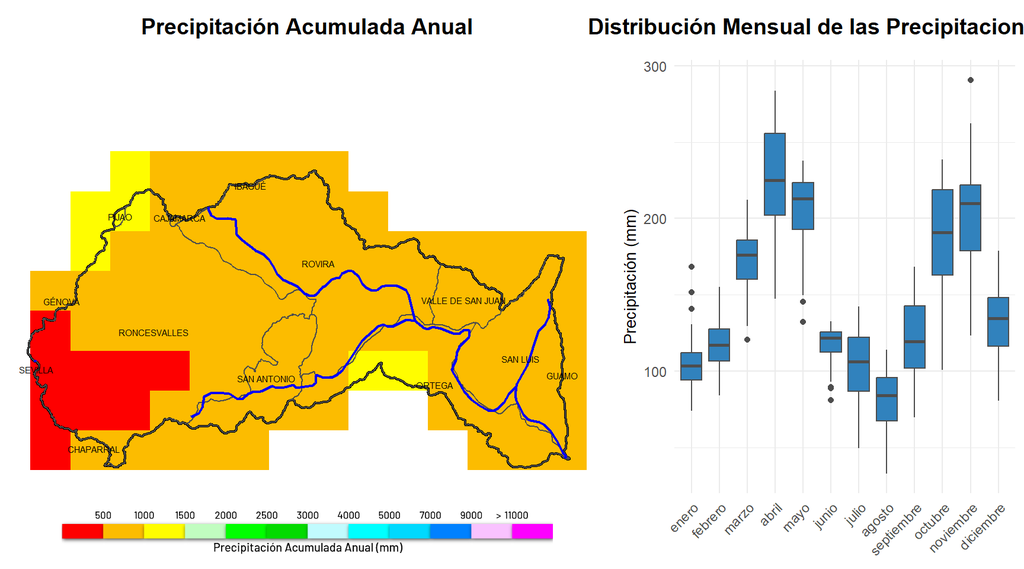

La cuenca Cucuana exhibe un régimen bimodal, caracterizado por dos temporadas secas al año. Las precipitaciones históricas en los próximos meses (agosto a enero) muestran un comportamiento variable que debe ser considerado por los productores.

En agosto, las precipitaciones son muy bajas, con una mediana de 84.2 mm, lo que representa un riesgo para cultivos que requieren humedad constante. Septiembre presenta un ligero aumento, alcanzando 119.6 mm, pero aún se considera relativamente limitado. En octubre, la mediana asciende a 190.7 mm, marcando un aumento significativo en las lluvias, lo que favorece el crecimiento de ciertos cultivos. Noviembre continúa con precipitaciones adecuadas (209.8 mm), lo que puede beneficiar las cosechas.

Diciembre muestra una disminución en las precipitaciones (134.8 mm), pero aún se mantiene un nivel que puede soportar cultivos de fin de año. En enero, las lluvias son moderadas (103.5 mm), lo que puede impactar la siembra de cultivos de ciclo corto.

### Predicción Climática (6 meses)

#### Análisis del comportamiento histórico de la precipitación en la cuenca Cuenca Cucuana

La cuenca Cuenca Cucuana presenta un régimen de lluvias caracterizado por variaciones significativas en los meses venideros, especialmente en el segundo semestre del año. Históricamente, las precipitaciones acumuladas en esta cuenca muestran un patrón que puede ser clasificado como sigue:

- **Agosto**: La mediana de 85.3 mm se sitúa en el rango de “bajo”, indicando niveles de lluvia limitados que pueden afectar la disponibilidad de agua en la región.
- **Septiembre**: Con 116.9 mm, se mantiene en el rango “bajo”, lo que sugiere que la situación de los afluentes aún es crítica pero comienza a mejorar ligeramente.
- **Octubre**: Al alcanzar 189.5 mm, las precipitaciones entran en la categoría de “normal”, lo que podría contribuir a la recuperación de los niveles de los ríos y mejorar la disponibilidad de agua para los cultivos.
- **Noviembre**: Con 206.2 mm, se considera “normal”, consolidando el aumento en la disponibilidad de agua, vital para la agricultura y el bienestar de los ecosistemas locales.
- **Diciembre**: La mediana de 133.5 mm cae nuevamente en la categoría “bajo”, lo que podría afectar la continuidad del suministro de agua hacia el final del año.
- **Enero**: Con 97.3 mm, se mantiene en la categoría “bajo”, lo que puede implicar un riesgo de escasez de agua para el inicio del ciclo agrícola.

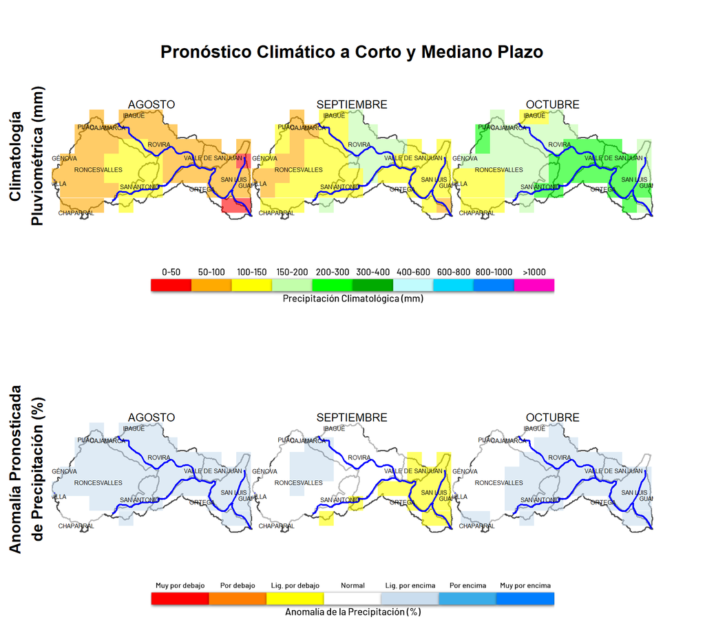

#### Análisis de Cambio de Precipitación en la Cuenca Cucuana

Las proyecciones de cambio en la precipitación acumulada para la cuenca Cucuana indican una tendencia de incremento en los meses siguientes. Para el mes de agosto de 2025, se prevé un **incremento moderado** del 14.1%, lo que sugiere un inicio favorable para el ciclo agrícola. En septiembre, el cambio se mantendrá en un **incremento leve** del 3.9%, lo que podría influir en las condiciones de cultivo de manera positiva, aunque de forma menos pronunciada.

A partir de octubre, se anticipa un **incremento significativo** del 13.1%, lo que puede favorecer la acumulación de humedad en el suelo, crucial para el desarrollo de los cultivos. En noviembre, el pronóstico se eleva aún más, con un **incremento considerable** del 19.3%, indicando un potencial para un crecimiento robusto de la vegetación.

Para diciembre, se espera un **incremento moderado** del 7.7%, seguido de otro **incremento considerable** en enero de 2026, con un 19.4%. Este patrón de aumento sostenido en la precipitación puede ser beneficioso para la agricultura, pero también podría plantear desafíos en términos de manejo del agua y riesgos de inundaciones. Es fundamental que los agricultores y planificadores adapten sus estrategias para aprovechar estas condiciones climáticas cambiantes.

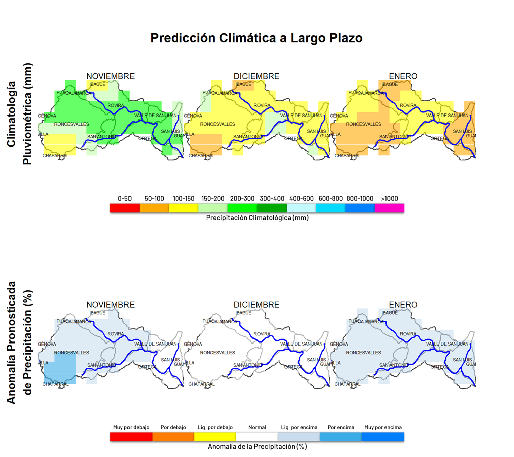

#### Evolución de los Volúmenes de Lluvia en la Cuenca Cucuana

Se prevé que la cuenca Cucuana experimentará un aumento significativo en los volúmenes de precipitación a lo largo de los próximos meses. Los modelos indican que para agosto de 2025 se pronostican aproximadamente **97.0 mm** de lluvia, con una probabilidad de acierto del **62%**. Esta cifra sugiere un inicio moderado de la temporada lluviosa.

Para septiembre, el pronóstico asciende a **119.9 mm**, con una probabilidad de acierto del **59%**, lo que indica cierta incertidumbre en la cantidad esperada. En octubre, se anticipa un aumento notable, alcanzando **212.5 mm** con una probabilidad del **61%**. Este mes podría ser crucial, ya que un desbordamiento de lluvias podría generar riesgos de inundaciones si se superan los **300 mm**.

En noviembre, el volumen de precipitación se incrementa aún más, con **235.1 mm** pronosticados y una probabilidad de acierto del **68%**. Esta tendencia sugiere que la cuenca podría enfrentar un elevado riesgo de inundaciones, especialmente si las lluvias son más intensas de lo proyectado.

Para diciembre, la expectativa es de **141.4 mm**, disminuyendo levemente, pero con un **60%** de probabilidad de acierto. Finalmente, en enero de 2026, se prevé una nueva disminución a **116.3 mm** con un **66%** de probabilidad de acierto.

### Pronóstico de tiempo (7 dias)

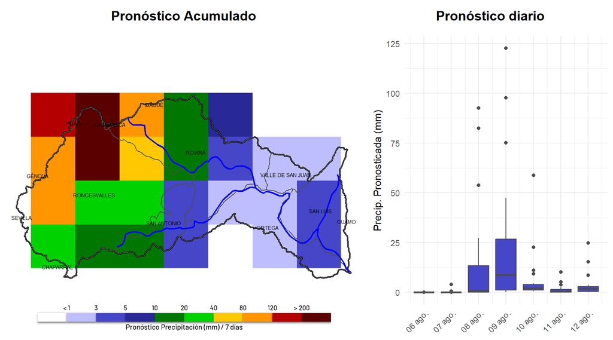

Para la cuenca **Cuenca_Cucuana**, se prevé una semana con variabilidad en las precipitaciones. Los días 8 y 9 de agosto se anticipan volúmenes significativos, con precipitaciones moderadas a intensas. En particular, el 9 de agosto se espera que las lluvias alcancen un rango elevado, lo que podría generar acumulaciones considerables. El 10 de agosto se pronostica una disminución en la intensidad de las lluvias, con volúmenes leves, seguido de un regreso a las precipitaciones ligeras el 11 y 12 de agosto.

En cuanto a las probabilidades de tiempo húmedo, se observa que el 8 de agosto presenta un 55% de probabilidad, sugiriendo buenas oportunidades de lluvias. El 9 de agosto muestra un notable aumento con un 85%, lo que indica altas probabilidades de tiempo húmedo. Para el 10 de agosto, la probabilidad se eleva al 100%, lo que sugiere condiciones muy favorables para la lluvia. Posteriormente, el 11 y 12 de agosto mantiene probabilidades alrededor del 50% y 65%, respectivamente, lo que implica buenas oportunidades de precipitaciones, aunque con menor intensidad.

### Seguimiento Meteorológico

**Nota:** para esta cuenca no existe información meteorológica.

## Cuenca Coello - Tolima

La cuenca del río Coello, localizada en el departamento del Tolima, drena una extensión de aproximadamente 1842 km² —cerca del 7,8 % de la superficie departamental— y forma parte de la gran cuenca del Magdalena . Su nacimiento se ubica en el Parque Nacional Natural Los Nevados, a más de 5000 m.s.n.m., y recorre un marcado gradiente altitudinal hasta su confluencia con el Magdalena en los valles bajos. Dentro de su ámbito hidrográfico se encuentra la subcuenca del río Combeima, que abastece más del 80 % del agua potable de Ibagué.

El territorio de la cuenca abarca parcial o totalmente a los municipios de Ibagué, Cajamarca, Rovira, San Luis, Espinal, Coello y Flandes, incorporando paisajes que van desde páramos y bosques altoandinos hasta llanuras aluviales. En las laderas se cultivan café y frutales, mientras que en la planicie del valle y en los distritos de riego Coello–Cucuana se destinan hectáreas al cultivo de arroz, caña de azúcar y hortalizas.

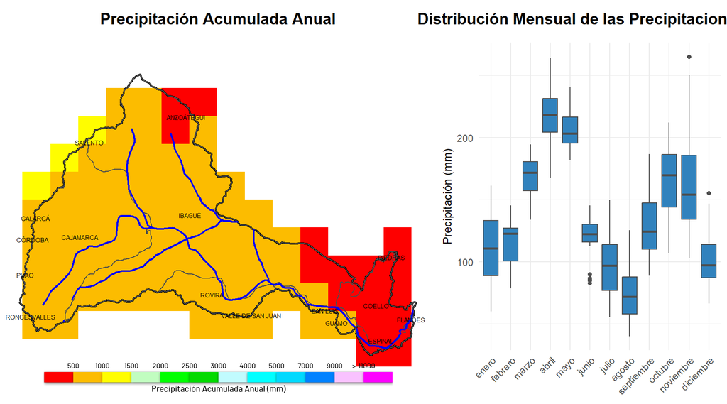

Octubre marca el inicio de un aumento significativo en las precipitaciones, con una mediana de 169.6 mm, lo que favorece la producción agrícola. Noviembre también presenta precipitaciones adecuadas, con una mediana de 154.2 mm, lo que continúa beneficiando los cultivos. Sin embargo, en diciembre, las precipitaciones vuelven a descender a niveles bajos, con solo 97.3 mm, lo que puede generar estrés hídrico en los cultivos establecidos.

Para los productores, es fundamental planificar cuidadosamente las siembras y las actividades agrícolas en función de estos patrones. Durante los meses de menor precipitación, se recomienda implementar prácticas de conservación de agua y considerar cultivos que sean más tolerantes a la sequía, mientras que en los meses de mayor precipitación, se debe prestar atención a la gestión del agua para evitar encharcamientos que puedan afectar la producción.

### Predicción Climática (6 meses)

#### Análisis del comportamiento histórico de la precipitación en la cuenca Cuenca Coello

El régimen de lluvias en la cuenca Cuenca Coello presenta variaciones significativas a lo largo del año, especialmente en los próximos seis meses. Los datos climatológicos indican que en agosto, la precipitación media es de 75.9 mm, lo que se considera un nivel bajo, lo que puede afectar la disponibilidad de agua en los afluentes de la cuenca. En septiembre, las lluvias aumentan a 128.8 mm, todavía dentro de la categoría de bajo, pero que comienza a mostrar una tendencia ascendente hacia la normalidad.

En octubre, se registra un incremento notable, alcanzando una mediana de 161.8 mm, lo que se clasifica como normal. Este aumento en la precipitación puede contribuir a una mejor recarga de los cuerpos de agua en la cuenca y a una mayor disponibilidad para los cultivos. Sin embargo, en noviembre, la precipitación se mantiene elevada con 152.6 mm, lo que sigue siendo normal y podría generar situaciones de riesgo si se acumulan lluvias excesivas.

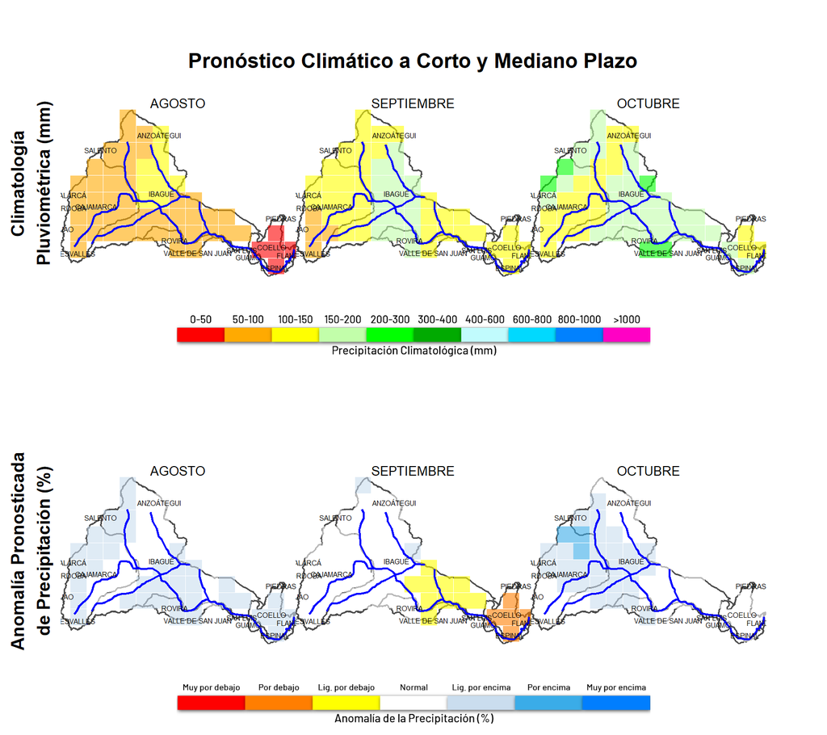

#### Análisis de Cambio de Precipitación en la Cuenca Coello

Las proyecciones de cambio de precipitación acumulada para la cuenca Coello muestran una tendencia general de incremento en la mayoría de los meses analizados. Para agosto de 2025, se anticipa un **incremento moderado** del 10.9%, lo que podría beneficiar el suministro de agua para los cultivos. Sin embargo, en septiembre de 2025, se prevé una **reducción ligera** del 1.3%, lo que podría generar cierta incertidumbre en la disponibilidad hídrica.

A partir de octubre de 2025, las proyecciones indican un **incremento significativo** en la precipitación, con un 10.2% en ese mes, seguido de un **aumento considerable** del 14.1% en noviembre. Este patrón de crecimiento se mantiene en diciembre de 2025, con un **incremento moderado** del 6.5%. Finalmente, en enero de 2026, se espera un **aumento fuerte** del 16.3%, lo que podría tener un impacto positivo en el desarrollo de los cultivos en la región.

En resumen, las proyecciones apuntan a un predominante aumento de la precipitación en la cuenca Coello durante el período analizado, lo que podría facilitar la actividad agrícola, aunque se debe estar alerta ante la ligera reducción pronosticada para septiembre.

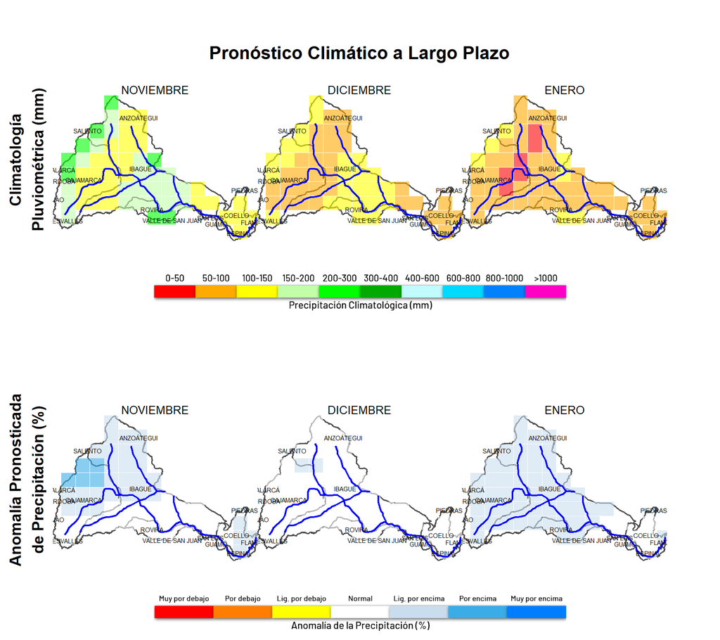

#### Evolución de la lluvia en la cuenca Coello

Se prevé que la cuenca Coello experimentará un aumento gradual en los volúmenes de precipitación a lo largo de los próximos meses. Para agosto de 2025, los modelos indican que se pronostican aproximadamente 85.3 mm de lluvia, con una probabilidad de acierto del 60%. Aunque la probabilidad no es alta, se espera que este volumen inicial sirva como un indicativo del inicio de una temporada más húmeda.

En septiembre, se anticipa un notable incremento en la precipitación, alcanzando los 125.6 mm. Sin embargo, con una probabilidad de acierto del 55%, esta predicción presenta una baja fiabilidad. Para octubre, el pronóstico asciende a 178.5 mm con un 59% de probabilidad de acierto, lo que sugiere una mayor incertidumbre. Este mes podría ser crítico, ya que, si se superan los 300 mm, se podrían presentar riesgos significativos de inundaciones.

En noviembre, se espera que las precipitaciones se mantengan en 165.9 mm, con una probabilidad de acierto más confiable del 66%. Diciembre presenta una ligera disminución a 100.1 mm, con un 58% de probabilidad, mientras que en enero de 2026, se proyectan 82.5 mm con un 64% de probabilidad de acierto.

#### Riesgos asociados

Es importante destacar que cualquier acumulación de lluvia superior a 300 mm podría resultar en inundaciones, lo que representa un riesgo significativo para la zona. Por otro lado, volúmenes inferiores a 50 mm podrían generar estrés hídrico en los cultivos, afectando la producción agrícola local.

En resumen, la variabilidad en la probabilidad de acierto, especialmente en los meses de septiembre y octubre, sugiere que se debe monitorear constantemente las condiciones climáticas para una adecuada gestión de recursos hídricos.

### Pronóstico de tiempo (7 dias)

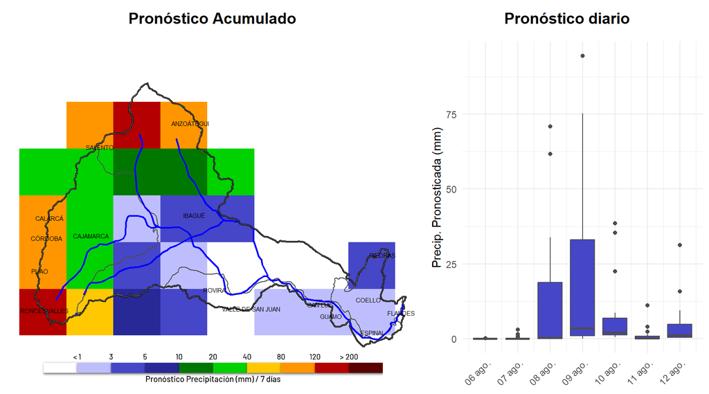

Para la cuenca **Cuenca_Coello**, se prevé una semana con variabilidad en la precipitación. Los días con mayores volúmenes esperados son el 8 y 9 de agosto, donde se anticipan precipitaciones intensas, con rangos que pueden considerarse elevados. El 10 de agosto también se espera un día con volúmenes moderados de lluvia, lo que podría contribuir a un aumento significativo en la humedad del suelo. En contraste, los días 6, 7 y 11 presentan condiciones de sequía, con probabilidades de tiempo seco bastante altas.

En cuanto a las probabilidades de tiempo húmedo, el 8 de agosto muestra un 50% de puntos con lluvia, lo que indica buenas probabilidades de condiciones húmedas. El 9 de agosto incrementa a un 77.8%, lo que sugiere que es muy probable que ocurran lluvias significativas. Para el 10 de agosto, las probabilidades alcanzan cerca del 100%, lo que implica una alta certeza de que habrá precipitaciones. Sin embargo, el 11 de agosto presenta un descenso en las probabilidades, con un 33.3%, lo que sugiere que el tiempo seco podría regresar. Finalmente, el 12 de agosto muestra nuevamente buenas probabilidades de tiempo húmedo con un 77.8% de puntos con lluvia.

La combinación de estos factores sugiere que la cuenca experimentará un aumento temporal en la humedad, que puede ser beneficioso para la agricultura, aunque es esencial estar atentos a posibles inundaciones debido a las precipitaciones intensas esperadas (IDEAM - WRF COLOMBIA).

### Seguimiento Meteorológico

**Nota:** para esta cuenca no existe información meteorológica.

## Cuenca Saldaña - Tolima

La cuenca del río Saldaña, en el departamento del Tolima, es una de las más extensas y productivas de la región central de Colombia. Nace en el páramo de Santo Domingo (P.N.N. Nevado del Huila) a unos 3.700 m.s.n.m. y desemboca en el río Magdalena a 272 m, recorriendo más de 300 km a lo largo de su cauce . Su área de influencia abarca aproximadamente 9800 km² —casi el 42 % del territorio tolimense—, constituyendo el mayor sistema hídrico del departamento .

Administrativamente, la cuenca comprende los municipios de Saldaña (40 % del beneficio) y Purificación (60 %) a través del Distrito de Riego del río Saldaña, con bocatoma en Puerto de Santa Marta y un canal principal de 13 km que distribuye entre 14000 ha de uso agrícola en un área de influencia de 37000 ha . Su red de afluentes incluye, entre otros, los ríos Cucuana, Luisa, Amoyá y Anamichú, que aportan caudales esenciales para el riego de arroz, caña, palma africana y otros cultivos de pan coger (yuca, plátano, cítricos).

Desde el punto de vista ecológico, la cuenca transita desde páramos andinos hasta pisos térmicos cálidos, favoreciendo una gran diversidad de hábitats y especies. Socioeconómicamente, el río Saldaña es vital: garantiza el abastecimiento de agua para riego, energía y uso doméstico, al tiempo que sostiene la economía local y la seguridad alimentaria de miles de agricultores.

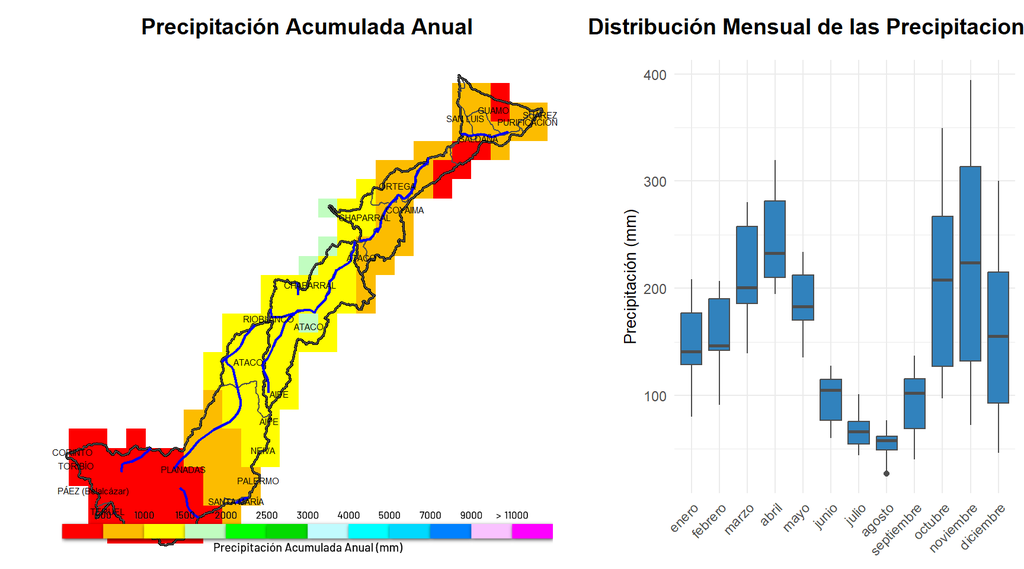

El comportamiento histórico de las precipitaciones en la cuenca Completa Saldana durante los próximos meses revela una tendencia bimodal, caracterizada por dos temporadas secas al año. La primera fase seca ocurre entre julio y agosto, donde las precipitaciones son muy bajas, con mediana de 66.1 mm y 57.8 mm, respectivamente. La segunda fase seca se presenta entre enero y principios de febrero, con precipitaciones relativamente limitadas.

En agosto y septiembre, las precipitaciones tienden a ser limitadas, con una mediana de 57.8 mm y 102.2 mm, lo que puede generar estrés hídrico en los cultivos. A medida que se avanza hacia octubre y noviembre, se observa un aumento significativo en las precipitaciones, alcanzando los 208 mm y 223.8 mm, indicando condiciones más favorables para el crecimiento de los cultivos. Diciembre también muestra precipitaciones relativamente limitadas, con 155.1 mm, lo que podría afectar la siembra de cultivos de ciclo corto que dependen de agua adecuada.

Para los productores, se recomienda planificar la siembra de cultivos que requieran mayor humedad para octubre y noviembre, mientras que en los meses de baja precipitación, como julio y agosto, se deben implementar técnicas de conservación de agua y manejo del suelo para mitigar la falta de humedad.

### Predicción Climática (6 meses)

#### Análisis del comportamiento histórico de la precipitación en la cuenca Cuenca Completa Saldaña

El régimen de lluvias en la cuenca Cuenca Completa Saldaña presenta un comportamiento variable en los próximos seis meses. Históricamente, se observa que en agosto, las precipitaciones son moderadas, con medianas que fluctúan entre 47.6 mm y 61.7 mm, lo que se clasifica como niveles críticos y muy bajos, lo que puede afectar la disponibilidad de agua para los cultivos.

En septiembre, las lluvias aumentan significativamente, con medianas que oscilan entre 79.4 mm y 125.4 mm. Este rango se considera bajo, aún insuficiente para una recarga adecuada de los afluentes. Sin embargo, se manifiesta un aumento en el riesgo de sequías temporales que pueden afectar la producción agrícola.

El mes de octubre muestra un cambio drástico en el patrón de lluvias, con medianas que varían entre 153.7 mm y 300.6 mm, lo que se clasifica como normal a intenso. Esta cantidad de lluvia puede provocar crecientes en los ríos y un riesgo elevado de desbordamientos, lo que requiere atención para la gestión del agua en la cuenca.

En noviembre, las precipitaciones se mantienen en niveles altos, con medianas de entre 168.8 mm y 352.4 mm. Aquí, la mediana más alta supera los 300 mm, lo que indica un riesgo considerable de desbordamientos y afectaciones a la infraestructura.

Finalmente, en diciembre y enero, las medianas varían entre 96.4 mm y 272.7 mm, donde diciembre muestra un comportamiento normal, pero enero presenta precipitaciones que pueden ser limitadas. En general, la cuenca presenta un comportamiento de lluvias que requiere una planificación cuidadosa para la gestión del agua y la agricultura.

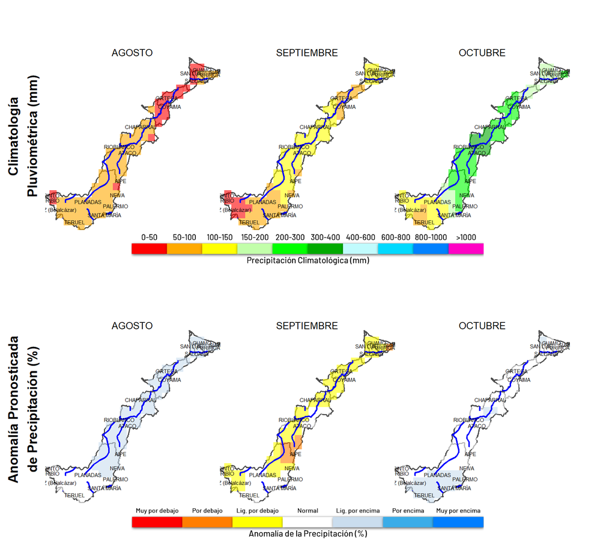

#### Análisis de Cambio de Precipitación en la Cuenca Completa Saldaña

Las proyecciones de cambio en la precipitación acumulada para la Cuenca Completa Saldaña durante el periodo de 2025 a 2026 muestran una tendencia variada. En agosto de 2025, se anticipa un **incremento moderado** en la precipitación, con cambios positivos que alcanzan hasta el 22.5%. Sin embargo, en septiembre de 2025, se prevé una **reducción importante**, con disminuciones en la precipitación que oscilan entre -13.0% y -18.8%, lo que podría tener un impacto significativo en la disponibilidad de agua para los cultivos.

A medida que se avanza hacia octubre y noviembre de 2025, se espera un **incremento leve** en la precipitación, con cambios positivos que rondan entre el 1.2% y el 9.6%. Esta tendencia podría ayudar a mitigar el déficit de agua que se podría experimentar en septiembre.

Durante diciembre de 2025 y enero de 2026, las proyecciones indican un **incremento moderado** en la precipitación, con valores que varían entre 5.1% y 13.1%. Este aumento podría ser beneficioso para la agricultura local, especialmente para el cultivo de arroz, al mejorar las condiciones de humedad en el suelo.

En resumen, la cuenca Saldaña enfrentará variaciones en la precipitación, con periodos de incremento y reducción que requerirán una gestión cuidadosa del agua.

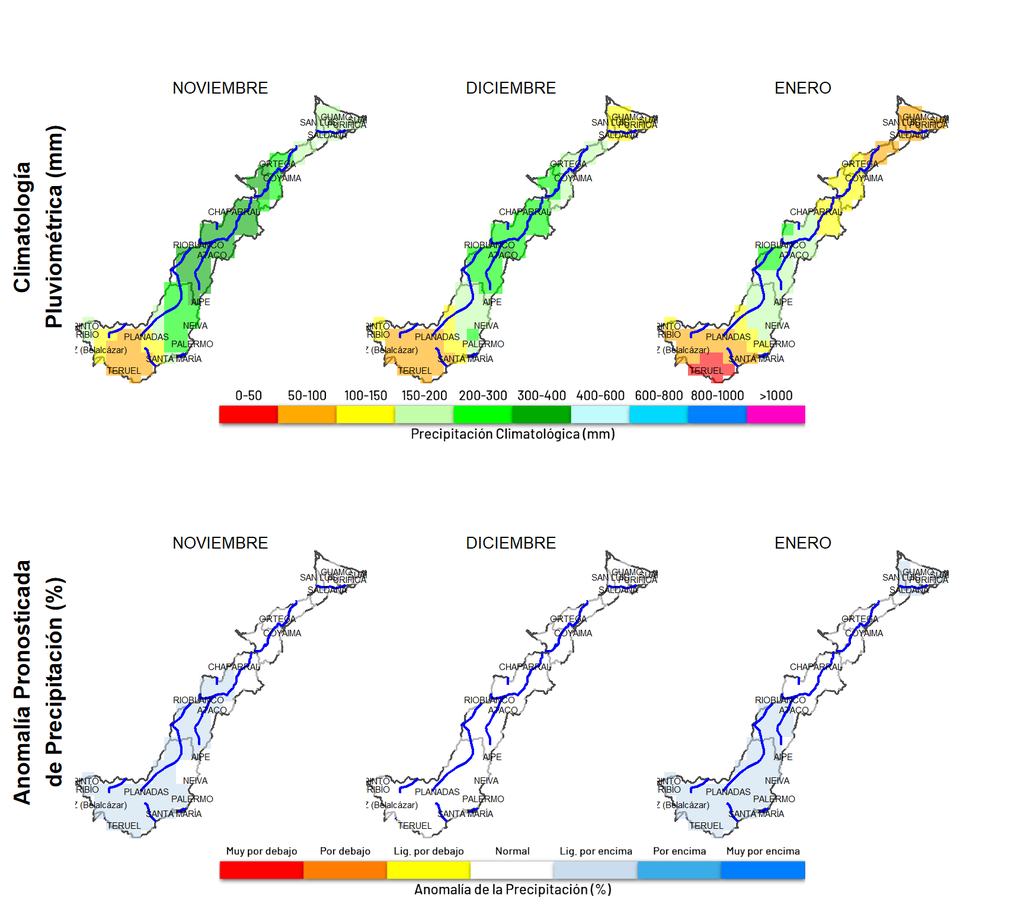

#### Pronóstico de Precipitación para la Cuenca Completa Saldana

Se prevé que los volúmenes de lluvia en la Cuenca Completa Saldana evolucionen de la siguiente manera en los próximos meses:

- **Agosto 2025:** Se pronostica una precipitación de 64.2 mm, con una probabilidad de acierto del 64%. Aunque la cantidad de lluvia es moderada, su probabilidad de acierto es relativamente baja, lo que podría generar incertidumbre en la planificación agrícola y la gestión de recursos hídricos.
- **Septiembre 2025:** Los modelos indican un incremento en la precipitación, alcanzando 86.6 mm, aunque la probabilidad de acierto desciende al 53%. Esto sugiere un riesgo de estrés hídrico en caso de que las lluvias sean inferiores a 50 mm.
- **Octubre 2025:** Se espera un notable aumento en la precipitación, con 231.8 mm pronosticados y un 57% de probabilidad de acierto. A pesar de que las lluvias serán significativamente más altas, la probabilidad de acierto sigue siendo moderada, lo que podría dificultar la previsión de inundaciones.
- **Noviembre 2025:** La precipitación podría alcanzar 268.4 mm, con una probabilidad de acierto del 61%. Si las lluvias superan los 300 mm, se incrementa el riesgo de inundaciones en la cuenca.
- **Diciembre 2025:** Se anticipa una precipitación de 195.3 mm y una probabilidad de acierto del 58%. El riesgo de estrés hídrico podría ser relevante si las lluvias son insuficientes.
- **Enero 2026:** Se espera que la precipitación baje a 138.5 mm, con un 61% de probabilidad de acierto. Esto podría ser un alivio temporal, pero se debe estar atento a la disponibilidad de agua para los cultivos.

#### Fiabilidad del Pronóstico

La probabilidad de acierto en los pronósticos es variable y, en general, se considera baja, especialmente para septiembre y octubre. Esta incertidumbre debe ser tomada en cuenta al planificar actividades agrícolas y la gestión de recursos hídricos en la cuenca.

### Pronóstico de tiempo (7 dias)

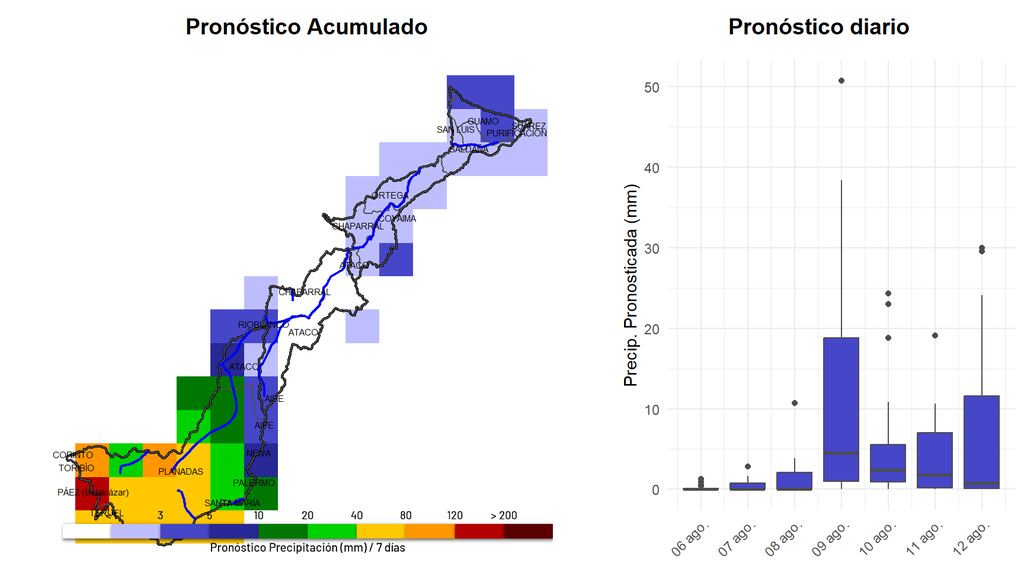

Para la cuenca **Cuenca_Completa_Saldana**, se prevén variaciones significativas en las precipitaciones a lo largo de la próxima semana. Los días con mayores volúmenes esperados son el 9 y el 12 de agosto, donde se anticipan precipitaciones intensas y moderadas, respectivamente. En el 9 de agosto, se prevén volúmenes elevados, lo que sugiere que podría haber un impacto significativo en el suelo y en la disponibilidad de agua para los cultivos. En el 12 de agosto, se esperan volúmenes moderados, lo que podría contribuir a mantener una humedad adecuada en el suelo, favoreciendo los cultivos.

En cuanto a las probabilidades de tiempo húmedo, se observan tendencias interesantes a lo largo de la semana. Desde el 9 de agosto, hay buenas probabilidades de tiempo húmedo, alcanzando hasta un 77.8% ese día. En los días siguientes, el 10 de agosto presenta altas probabilidades de humedad, con un 85.2%, manteniéndose en un rango alto hasta el 11 de agosto, donde las probabilidades se sitúan en un 63%. Finalmente, el 12 de agosto, aunque las probabilidades disminuyen, aún permanecen en un 51.9%, lo que sugiere que podría haber buen potencial de lluvias. En resumen, se anticipa una semana con un predominio de condiciones húmedas, especialmente hacia mediados de la semana, lo que podría ser beneficioso para la agricultura en la región. (IDEAM - WRF COLOMBIA)

### Seguimiento Meteorológico

**Nota:** para esta cuenca no existe información meteorológica.

# Cuencas Zona Llanos

## Cuenca Río Pauto

Desde el punto de vista productivo, la cuenca es fundamental para la agricultura y la ganadería de la región: sus fértiles suelos aluviales sostienen cultivos de arroz, maíz y plátano, así como pasturas para el ganado bovino. En sectores como la vereda El Garrancho se combinan plantaciones de arroz y pastos de corte, aprovechando tanto el riego directo del río como las napas freáticas.

Ecológicamente, la sabana inundable del Pauto alberga una rica biodiversidad (más de 600 especies de plantas y alrededor de 180 especies de aves), y sirve de corredor fluvial que conecta el piedemonte andino con la cuenca baja del Orinoco. Su manejo integrado resulta clave para garantizar el abastecimiento de agua durante la estación seca y para mitigar inundaciones extremas en los meses de mayor caudal.

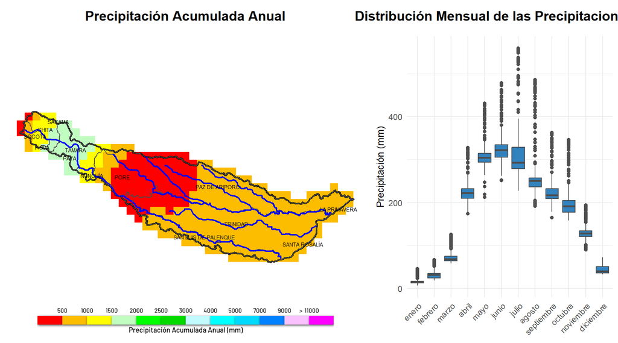

La cuenca Pauto Casanare presenta un comportamiento pluviométrico monomodal, caracterizado por una temporada seca y un período de lluvias concentradas. Históricamente, la estación seca se presenta entre diciembre y enero, donde las precipitaciones son muy bajas, con un promedio de 39.9 mm en diciembre y 14.8 mm en enero. Esto implica un riesgo para los cultivos que dependen de la humedad constante.

En noviembre y diciembre, las precipitaciones disminuyen nuevamente, lo que puede afectar la cosecha si no se planifica la siembra de cultivos de ciclo corto. Para los productores, se recomienda aprovechar las lluvias de medio a fuerte en julio y agosto, y considerar cultivos que se adapten a la reducción de lluvias en noviembre y diciembre. Es fundamental implementar prácticas de conservación de agua durante la estación seca para mitigar el impacto en la producción agrícola.

### Predicción Climática (6 meses)

#### Análisis del comportamiento histórico de la precipitación en la cuenca Cuenca Pauto Casanare

El comportamiento histórico de las precipitaciones en la cuenca Cuenca Pauto Casanare muestra un régimen de lluvias que varía significativamente a lo largo de los meses, especialmente en el periodo de agosto a enero. Durante estos meses, las precipitaciones presentan una tendencia decreciente, comenzando con una mediana de 249.5 mm en agosto, que se reduce a 16.3 mm en enero.

En septiembre, la mediana de precipitación es de 217.3 mm, lo que indica un nivel normal de lluvias, favorable para la recarga de acuíferos y el abastecimiento de agua en la región. Sin embargo, en octubre, la precipitación baja a 190.5 mm, manteniendo aún un nivel normal, aunque cercano al límite inferior de este rango.

A partir de noviembre, la mediana de lluvias desciende notablemente a 129.4 mm, situándose en el umbral bajo, lo que puede impactar negativamente en los niveles de los ríos y en la disponibilidad de agua para los cultivos. En diciembre, la mediana se reduce aún más a 39.4 mm, lo que se considera muy bajo y puede generar preocupaciones sobre los niveles críticos de los afluentes. Finalmente, en enero, se registra una mediana de 16.3 mm, lo que agrava la situación de escasez hídrica en la cuenca.

Es importante resaltar que, a lo largo de estos meses, ninguna mediana histórica supera los 300 mm, lo que implica que no existen riesgos de crecientes o desbordamientos en la cuenca. Sin embargo, las medianas por debajo de 100 mm en diciembre y enero podrían afectar considerablemente la disponibilidad de agua para las actividades agrícolas, especialmente en el cultivo de arroz, que depende en gran medida de un suministro adecuado de agua.

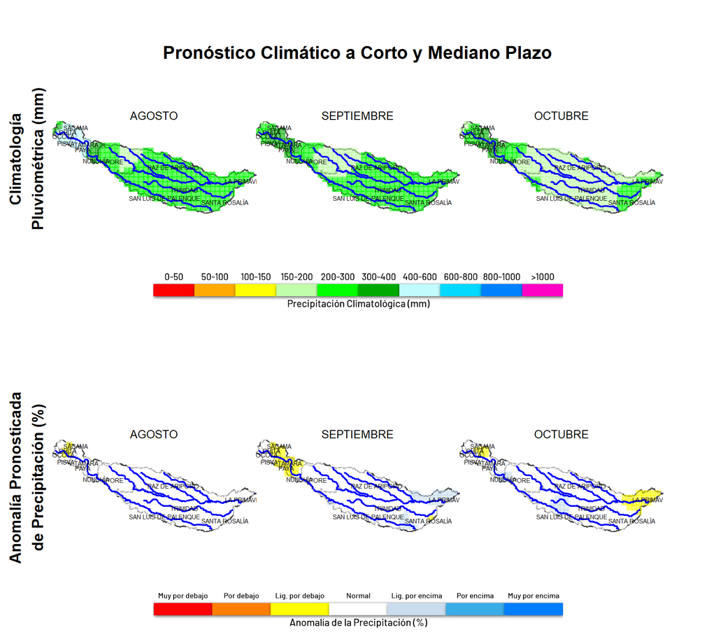

#### Análisis de Cambios en Precipitación para la Cuenca Pauto Casanare

La cuenca Pauto Casanare experimentará diversas variaciones en la precipitación acumulada en los próximos meses. A partir de agosto de 2025, se prevé un ligero decremento del 0.9%, lo que indica un inicio moderado de sequía o reducción en las lluvias. Sin embargo, en septiembre, se anticipa un leve aumento del 0.7%, sugiriendo una ligera recuperación en las condiciones hídricas.

Los meses siguientes muestran una tendencia de incremento más pronunciado. En octubre de 2025, se estimará un aumento del 1.3%, seguido por un incremento significativo del 6.1% en noviembre. Este patrón de aumento continúa en diciembre con un 8.2%. Finalmente, enero de 2026 se proyecta como el mes con el mayor incremento, alcanzando un notable 25.1%.

En resumen, la cuenca Pauto Casanare experimentará inicialmente fluctuaciones menores, con una tendencia hacia un incremento moderado y considerable en las precipitaciones hacia finales de 2025 y principios de 2026. Este cambio podría tener implicaciones significativas para la agricultura y la gestión de recursos hídricos en la región, especialmente en el cultivo de arroz, que es sensible a las variaciones en las precipitaciones.

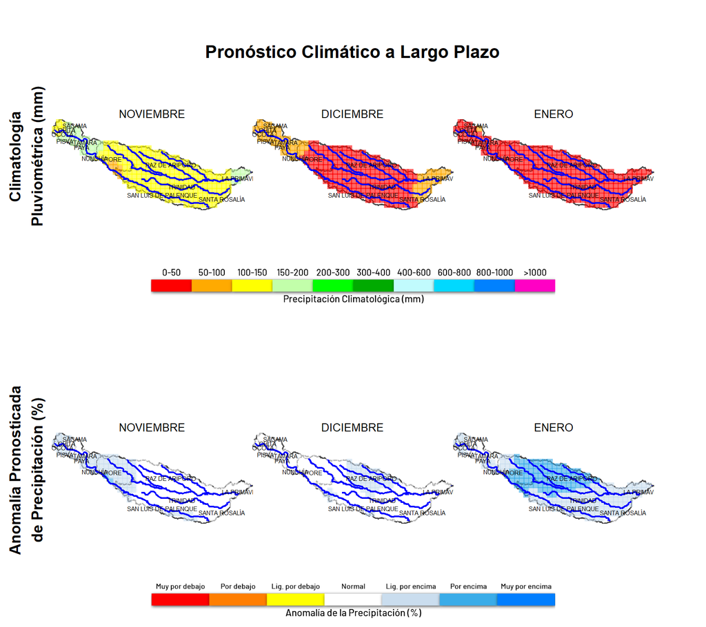

#### Evolución de la Precipitación en la Cuenca Pauto Casanare

Se prevé que la cuenca Pauto Casanare experimente un patrón de precipitación fluctuante en los próximos meses. Los modelos indican que para agosto de 2025, se pronostican aproximadamente **247.9 mm** de lluvia, con una probabilidad de acierto del **52%**. Este valor sugiere un riesgo moderado de inundaciones si se superan los **300 mm**, aunque la probabilidad de que esto ocurra es baja.

Para septiembre, se anticipa una disminución en la precipitación, con **228.1 mm** pronosticados y una probabilidad de acierto del **51%**. La tendencia a la baja continúa en octubre, donde se prevén **186.5 mm**, con una probabilidad de acierto del **61%**. Aunque la probabilidad de acierto es moderada, esto podría generar condiciones más secas, acentuando el riesgo de estrés hídrico si la lluvia baja de **50 mm** en algún momento.

En noviembre, se estima que la precipitación descenderá aún más a **135.5 mm**, con una probabilidad de acierto del **60%**. Para diciembre, se pronostican apenas **42.8 mm**, donde la probabilidad de acierto se mantiene en **59%**, lo que indica que es muy baja la probabilidad de que los volúmenes de lluvia sean precisos. Finalmente, enero de 2026 muestra un nuevo descenso a **20.2 mm**, con una probabilidad de acierto más alta del **69%**, aunque todavía bajo.

#### Conclusión

En resumen, la cuenca Pauto Casanare enfrentará un periodo de lluvias que se espera que disminuya significativamente hacia finales de 2025 y principios de 2026. Es crucial que los productores y gestores de recursos hídricos se preparen para estas variaciones, prestando especial atención a los riesgos de inundaciones y estrés hídrico.

### Pronóstico de tiempo (7 dias)

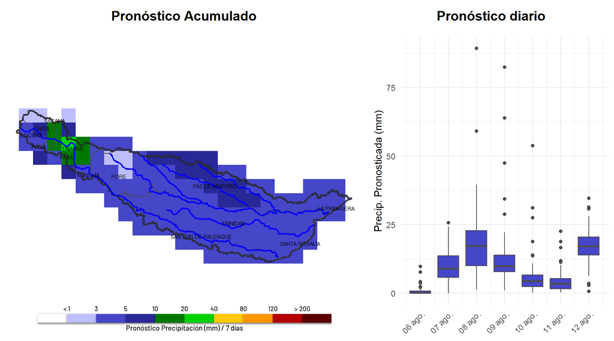

La cuenca **Cuenca_Pauto_Casanare** experimentará una semana con variaciones significativas en las precipitaciones. Los días más destacados en cuanto a volúmenes esperados serán el 8 y 12 de agosto, donde se anticipan precipitaciones intensas. Durante estos días, se prevén volúmenes elevados, con la mediana estimada alcanzando niveles notables. El 7 y 9 de agosto también se esperan precipitaciones intensas, aunque con volúmenes ligeramente menores, clasificándose como volúmenes moderados. En contraste, el 10 de agosto se prevén precipitaciones moderadas, que serán seguidas por lluvias leves el 11 de agosto, indicando una disminución en la intensidad de las precipitaciones.

Analizando las probabilidades de tiempo húmedo, el 6 de agosto muestra un 35.6%, lo que indica bajas probabilidades de lluvia. Sin embargo, a partir del 7 de agosto, las probabilidades aumentan drásticamente, alcanzando cerca del 100% desde el 8 hasta el 12 de agosto. Esto sugiere un alto potencial para condiciones húmedas en la cuenca durante estos días, lo que podría tener un impacto significativo en la agricultura local y la gestión de recursos hídricos. En resumen, se anticipa una semana mayormente húmeda que podría influir en la actividad agrícola de la región (IDEAM - WRF COLOMBIA).

### Seguimiento Meteorológico

**Nota:** para esta cuenca no existe información meteorológica.

## Cuenca Río Cusiana

La cuenca del río Cusiana, ubicada en la región suroriental de Casanare, cubre cerca de 3200 km² y comprende principalmente los municipios de Aguazul, Pajarito y Tauramena antes de confluir con el Meta. Su territorio se extiende desde las estribaciones orientales de la cordillera Oriental, a más de 1200 m s.n.m., hasta las llanuras inundables a 200 m s.n.m.

Economicamente, el valle del Cusiana es estratégico para la ganadería extensiva y los cultivos de arroz y maíz, cuyos sistemas de riego aprovechan tanto el cauce principal como los arroyos tributarios. Además, la cuenca alberga pozos de gas y petróleo en las inmediaciones de Campo Rubiales, generando un delicado balance entre la explotación de hidrocarburos y la conservación de sus ecosistemas ribereños.

Ambientalmente, la diversidad de bosques gallery y sabanas inundables sostiene poblaciones de mamíferos como el venado bogotano y una importante avifauna acuática. La gestión integrada del agua en la cuenca del Cusiana es esencial para mantener su función de amortiguamiento de avenidas, garantizar agua para riego durante la estación seca y proteger los hábitats tradicionales frente a la presión agrícola e industrial.

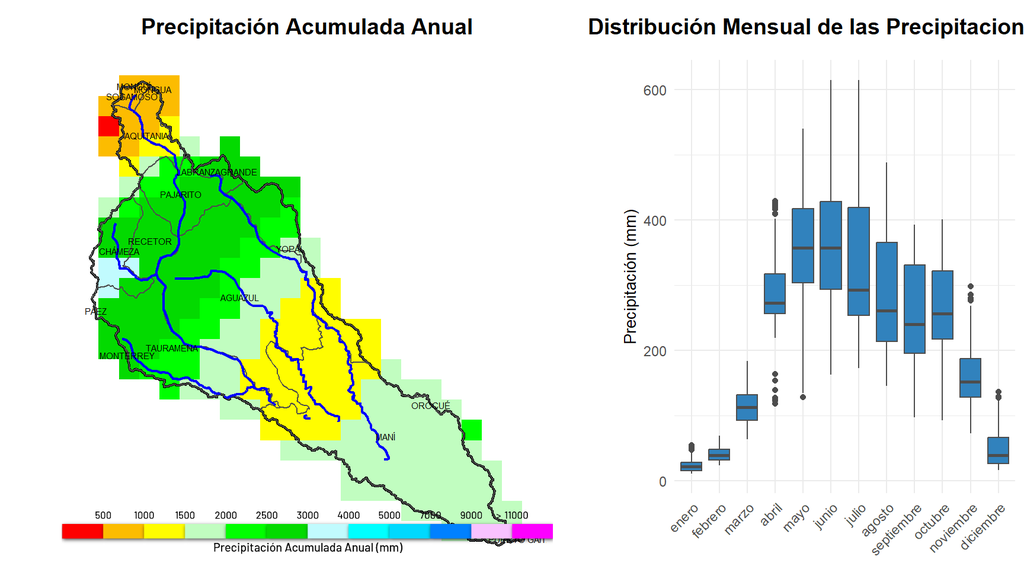

A partir de octubre, las precipitaciones continúan siendo adecuadas (mediana de 256.2 mm), pero empiezan a disminuir en noviembre (151.8 mm) y diciembre (39.5 mm), marcando el inicio de la temporada seca. Esta disminución puede impactar negativamente a los cultivos que dependen de la humedad constante.

La cuenca Cusiana Casanare presenta un régimen pluviométrico monomodal, con una única temporada seca al año. Esta temporada ocurre principalmente entre diciembre y enero, cuando las precipitaciones son muy bajas. Para los productores, es crucial planificar las siembras y cosechas considerando estos patrones; se recomienda maximizar la producción durante los meses de mayor precipitación y asegurar sistemas de riego adecuados para afrontar la temporada seca.

### Predicción Climática (6 meses)

#### Análisis del comportamiento histórico de la precipitación en la cuenca Cusiana Casanare

La cuenca Cusiana Casanare presenta un régimen de lluvias caracterizado por variaciones significativas en las precipitaciones a lo largo de los meses. Durante los próximos seis meses, se estima una mediana de precipitaciones que fluctúa entre 19.9 mm y 262.6 mm, lo que indica una transición de un periodo lluvioso a uno seco.

En agosto, se proyecta una precipitación mediana de 262.6 mm, lo que se clasifica como un nivel normal. Este mes es crucial para la recarga de los afluentes, lo que contribuye a la disponibilidad de agua en la región. En septiembre, la mediana se reduce a 241.9 mm, manteniendo un carácter normal, pero ya se observa una tendencia a la baja en las lluvias.

Octubre muestra un ligero aumento con 260.4 mm, aún en la categoría normal, seguido por noviembre, donde las precipitaciones caen a 158.2 mm, lo que sigue siendo un nivel aceptable, aunque con menores aportes a los cuerpos de agua. Sin embargo, en diciembre, la precipitación desciende drásticamente a 43.2 mm, entrando en la categoría de muy bajo, lo que representa un nivel crítico para los afluentes y puede afectar la disponibilidad de agua en la región. Finalmente, enero se prevé con 19.9 mm, reafirmando la fase seca del ciclo anual.

Es relevante mencionar que, aunque ninguna mediana histórica supera los 300 mm, diciembre presenta un nivel alarmante por debajo de 50 mm, lo que podría impactar negativamente en los niveles del río y la disponibilidad de agua para los cultivos, especialmente el arroz. Por tanto, es esencial monitorear estas condiciones para la planificación agrícola y la gestión del agua en la cuenca.

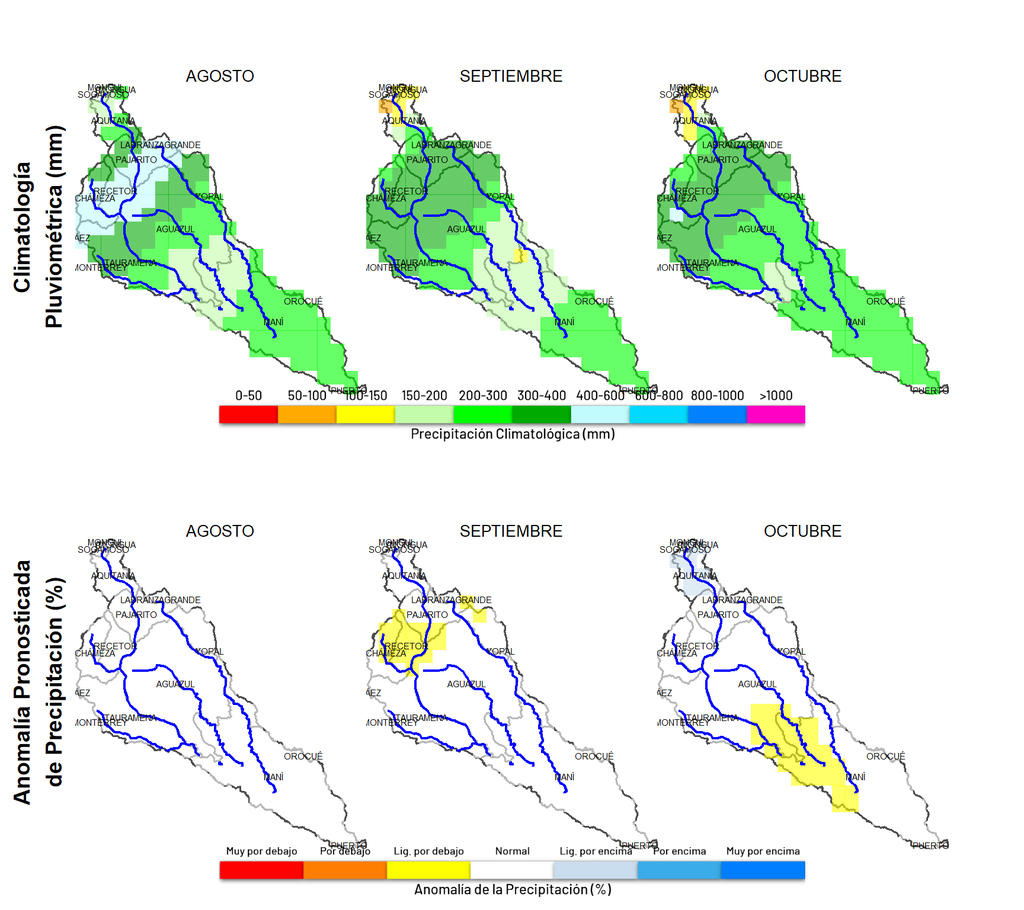

#### Análisis de Cambio de Precipitación en la Cuenca Cusiana Casanare

Para el período pronosticado entre agosto de 2025 y enero de 2026, se observa una tendencia variada en los cambios de precipitación acumulada en la cuenca Cusiana Casanare. En los meses de agosto a octubre de 2025, se prevé una **reducción moderada** en las precipitaciones, con cambios de -2.5%, -4.2% y -2.9%, respectivamente. Estos descensos sugieren que durante este periodo inicial, la cuenca podría experimentar condiciones más secas de lo habitual, lo que podría impactar negativamente en los cultivos y en la disponibilidad de agua.

Sin embargo, la tendencia cambia significativamente a partir de noviembre de 2025, donde se pronostica un **incremento notable** en las precipitaciones acumuladas. Noviembre presenta un cambio del 13.0%, seguido de diciembre con un 8.3% y enero de 2026 con un 15.8%. Este aumento sugiere que la cuenca podría experimentar un período de lluvias más intensas, lo que podría ser beneficioso para la recarga de acuíferos y la agricultura, siempre que no se presenten fenómenos de inundaciones.

En resumen, se anticipa un cambio inicial hacia condiciones más secas, seguido de un periodo de lluvias más abundantes, lo que requerirá una adecuada planificación en la gestión del agua y los cultivos.

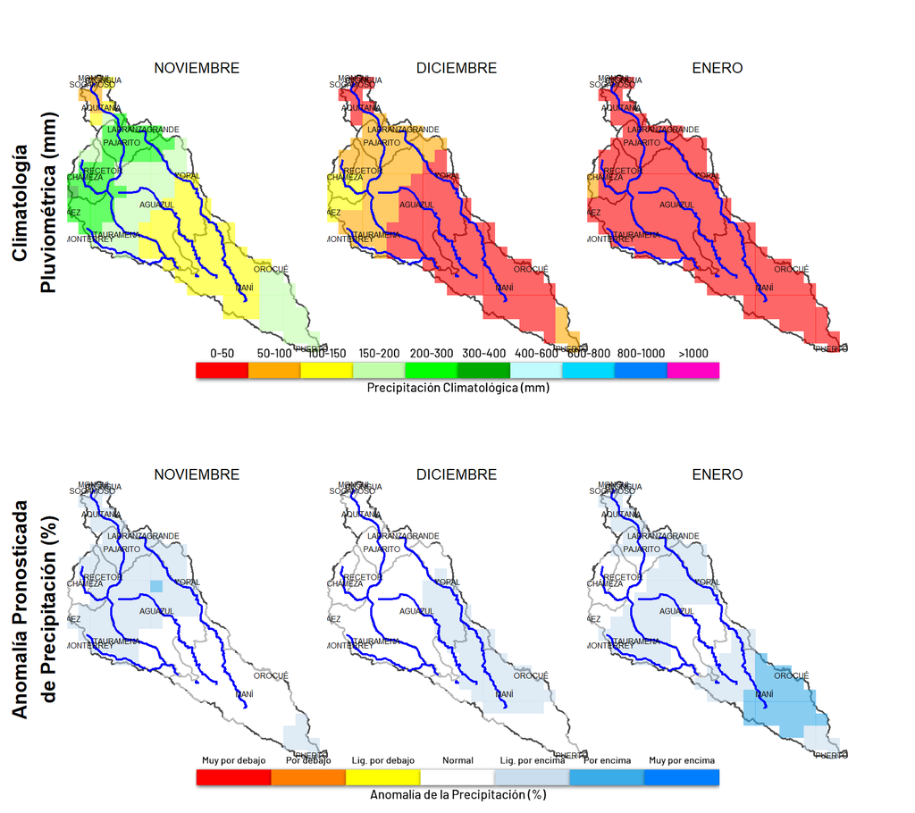

#### Evolución de la Precipitación en la Cuenca Cusiana Casanare

Se prevé que la cuenca Cusiana Casanare experimente un comportamiento variable en los volúmenes de precipitación durante los próximos meses. Para agosto de 2025, los modelos indican una precipitación pronosticada de 257.3 mm, con una probabilidad de acierto del 55%. Esto sugiere un riesgo moderado de inundaciones si los niveles de precipitación superan los 300 mm, aunque la incertidumbre en la predicción es considerable.

En septiembre, se anticipa una ligera disminución, con 234.8 mm pronosticados y una probabilidad de acierto del 54%. Aunque la precipitación se mantiene en niveles elevados, la probabilidad de acierto es baja, lo que introduce un grado significativo de incertidumbre en la previsión.

El mes de octubre presenta un pronóstico de 250.5 mm, con una probabilidad de acierto del 55%. A medida que se aproxima el final del año, en noviembre, se estima una caída marcada en la precipitación a 177.1 mm, con una probabilidad de acierto del 63%, lo que sugiere una mejora en la fiabilidad de esta predicción. Sin embargo, la cantidad de lluvia aún podría ser suficiente para generar inundaciones en caso de eventos extremos.

Para diciembre, se prevé un drástico descenso a 46.9 mm y una probabilidad de acierto del 61%, lo que podría indicar un riesgo de estrés hídrico para los cultivos si la lluvia se mantiene por debajo de 50 mm. Finalmente, en enero de 2026, se espera una precipitación aún más baja de 24.4 mm, con una probabilidad de acierto del 68%, lo que refuerza la tendencia de disminución en la disponibilidad de agua.

#### Conclusión

En resumen, se espera que la cuenca Cusiana experimente un ciclo de precipitaciones con altos volúmenes hasta noviembre, seguido de una notable reducción en diciembre y enero. La fiabilidad de las predicciones varía, siendo moderada en los primeros meses y mejorando hacia finales de año, aunque siempre con cierto grado de incertidumbre. Es crucial monitorear las condiciones climáticas para una gestión adecuada de los recursos hídricos en la región.

### Pronóstico de tiempo (7 dias)

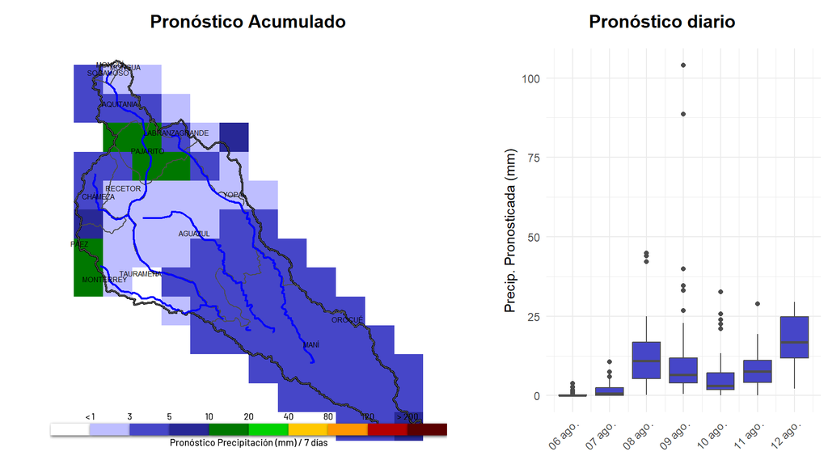

La próxima semana se prevé un patrón de precipitaciones variable en la Cuenca Cusiana Casanare. Los días 8 y 12 de agosto destacan por ser los de mayores volúmenes esperados, con precipitaciones intensas que podrían generar acumulaciones elevadas. El día 11 también muestra un potencial significativo de lluvias intensas, mientras que los días 9 y 10 se anticipan volúmenes moderados. Esto sugiere que, aunque habrá días con precipitaciones más ligeras, la tendencia general será hacia eventos de lluvia más fuertes y acumulativos hacia finales de la semana.

Las probabilidades de tiempo húmedo son notablemente altas. Para el día 8, se espera que aproximadamente el 98% de los puntos en la cuenca experimenten lluvias, lo que indica altas probabilidades de tiempo húmedo. Esta tendencia se mantiene con un 100% de probabilidad de lluvia tanto el 9 como el 12 de agosto, lo que refuerza la previsión de un entorno mayormente húmedo a lo largo de la semana. En general, la cuenca estará bajo un pronóstico de lluvias frecuentes y abundantes, particularmente en la mitad de la semana, lo que es favorable para el desarrollo agrícola, aunque también puede presentar desafíos relacionados con el manejo del agua y la erosión.

Fuente: IDEAM - WRF COLOMBIA.

### Seguimiento Meteorológico

**Nota:** para esta cuenca no existe información meteorológica.

## Cuenca Río Ariarí

La cuenca del río Ariari, porción central de los Llanos Orientales colombianos, abarca aproximadamente 5000 km² en el sur del Meta, incluyendo los municipios de Vista Hermosa, Puerto Rico y Mesetas. Se origina en las faldas orientales de la cordillera Oriental, a unos 1200 m s.n.m., y desciende al llano hasta los 200 m, donde confluye con el río Guayabero.

Su régimen hídrico sostiene amplias sabanas inundables y bosques de galeria a lo largo de sus márgenes, que albergan especies como el chigüiro y nutria de río, además de una variada avifauna (garzas, martín pescador).

Económicamente, la cuenca es clave para la ganadería extensiva y el cultivo de arroz y caña de azúcar, aprovechando sus cauces y canales de riego. Asimismo, en su cuenca alta se desarrollan proyectos de ecoturismo y conservación de bosques andinos, mientras que en el tramo medio y bajo la navegación fluvial y el trasporte de carga son vitales para las comunidades ribereñas.

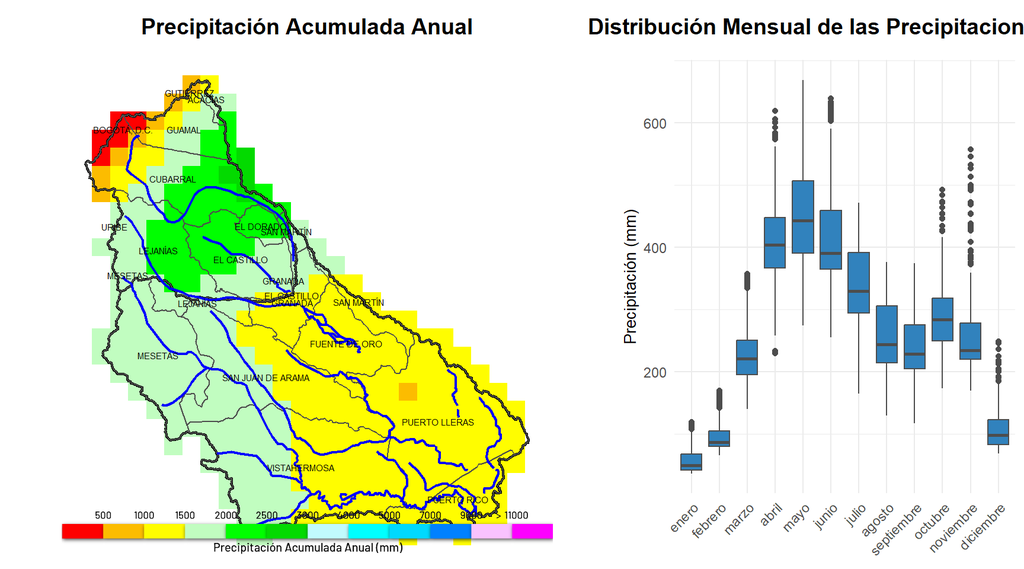

La cuenca Rio Ariari Meta presenta un régimen pluviométrico monomodal, caracterizado por una única temporada seca al año. Esta temporada se extiende de diciembre a febrero, donde las precipitaciones son notablemente más bajas. En este período, enero y febrero son los meses críticos, con precipitaciones medianas que apenas alcanzan los 49.7 mm y 86.4 mm, respectivamente.

Para los productores, es fundamental tener en cuenta el aumento de precipitaciones de marzo a julio y la posibilidad de inestabilidad climática durante este período. Las siembras deben planificarse para aprovechar las lluvias fuertes, especialmente en abril y mayo. En contraste, se debe estar preparado para la sequía de diciembre a febrero, considerando prácticas de conservación de agua y cultivos resistentes a la falta de humedad durante esos meses.

### Predicción Climática (6 meses)

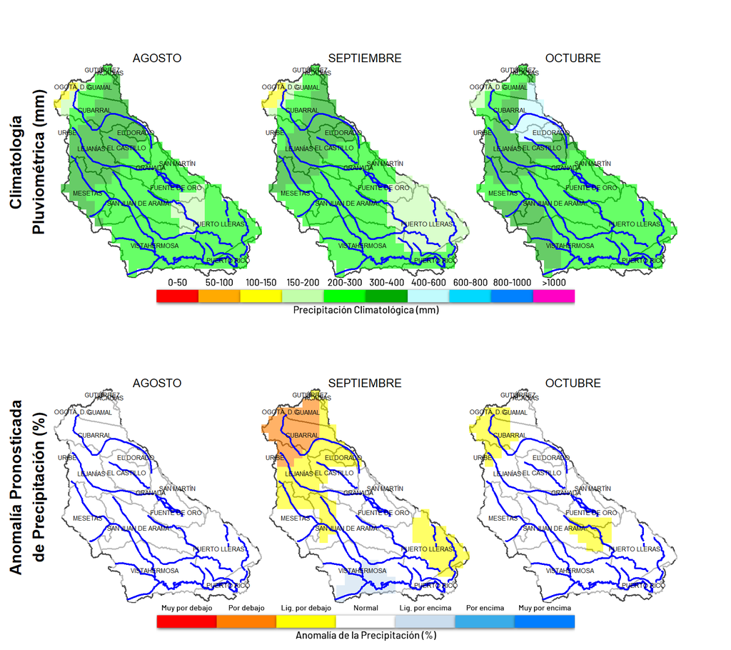

#### Análisis de Cambios en Precipitación para la Cuenca Río Ariari Meta

Las proyecciones de cambio en la precipitación acumulada para la Cuenca Río Ariari Meta entre 2025 y 2026 muestran una tendencia variada que sugiere un comportamiento irregular en la distribución de las lluvias.

Durante el mes de agosto de 2025, se prevé un ligero incremento del 1.4%, seguido de una reducción significativa del 3.9%. Sin embargo, en septiembre de 2025, se anticipa una reducción importante de hasta un 26.3%, complementada por una disminución adicional del 4.8%. Esta tendencia de reducción se mantiene en octubre con caídas del 6.5% y 4.8%, lo que indica un período de déficit hídrico considerable.

A pesar de estas reducciones, hacia finales de noviembre y diciembre de 2025, se prevé un cambio favorable con incrementos moderados del 4.8% y 8.4%, respectivamente. Esta tendencia positiva continúa en enero de 2026, con aumentos del 11.1% y 9.9%.

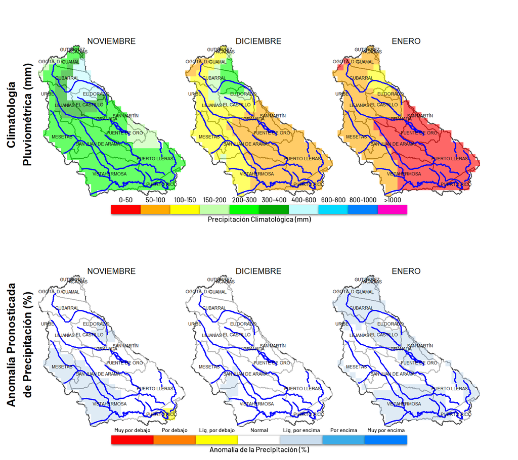

#### Pronóstico de Precipitación para la Cuenca Rio Ariari Meta

Se prevé que los volúmenes de precipitación en la Cuenca Rio Ariari Meta experimenten una variabilidad significativa en los próximos meses. Para agosto de 2025, los modelos indican que se pronostican aproximadamente **273.0 mm** de lluvia, con una probabilidad de acierto del **56%**. Esto sugiere una incertidumbre elevada, lo que puede dificultar la planificación agrícola.

En septiembre, se anticipa una ligera disminución en la precipitación, con **237.8 mm** pronosticados y una probabilidad de acierto del **61%**. Aunque este valor sugiere menos lluvia, la probabilidad aún se considera moderada, lo que implica que se debe mantener la vigilancia sobre el estado hídrico de los cultivos.

Para octubre, la situación se complica, ya que se esperan **292.0 mm**, con un **54%** de probabilidad de acierto. Este nivel de precipitación está muy cerca del umbral crítico de **300 mm**, lo que podría aumentar el riesgo de inundaciones en la cuenca si se superan esos valores.

En noviembre, se pronostica un aumento significativo, con **307.9 mm** y una probabilidad de acierto del **61%**, lo que representa un riesgo elevado de inundaciones. En diciembre, la situación cambia drásticamente, con una disminución a **126.5 mm** y un **60%** de probabilidad, lo que podría generar condiciones de estrés hídrico si se llega a un volumen de **50 mm**.

Finalmente, en enero de 2026, se espera un descenso a **64.1 mm** con una probabilidad de acierto del **64%**. Esta tendencia sugiere que la cuenca podría enfrentar un periodo prolongado de sequía, lo que afectaría negativamente a los cultivos.

En resumen, la variabilidad en las precipitaciones y la probabilidad de acierto en los pronósticos deben ser consideradas cuidadosamente para la gestión de recursos hídricos en la cuenca.